# An Introduction to Python

*Institute of Neural Information Processing at the University of Ulm*

This is a short introduction to Python which we are using in our lectures. Python is a free programming language and very easy to use.

## Installation

For scientific programming, we recommend Anaconda as Python distribution since it contains a package and environment manager and it comes pre-installed with many useful packages. For our lectures, you need to set up your environment as follows:

- Install Anaconda: https://www.anaconda.com/download/
- Install NodeJS: `conda install nodejs`
- Install the [matplotlib Jupyter extension](https://github.com/matplotlib/jupyter-matplotlib) (required for interactive widgets)
  - `conda install -c conda-forge ipympl`
  - `jupyter labextension install @jupyter-widgets/jupyterlab-manager`
  - `jupyter labextension install jupyter-matplotlib`
- (Optional) Install the [variable explorer](https://github.com/lckr/jupyterlab-variableInspector): `jupyter labextension install @lckr/jupyterlab_variableinspector`

After the installation, you can navigate to a folder and start the Jupyter environment via `jupyter lab`. Some general tips to work efficiently in the lab can be found in [this blog post](https://florianwilhelm.info/2018/11/working_efficiently_with_jupyter_lab/).

## Keyboard Shortcuts

There are three important keyboard shortcuts when using the Jupyter lab:

- `SHIFT + ENTER`: execute a cell.
- `SHIFT + TAB`: open the documentation for the current element.
- `TAB`: autocompletion.

## Package Management

There are two possibilities to install new packages, see https://conda.io/docs/user-guide/tasks/manage-pkgs.html:

- packages from Anaconda
- non-conda packages

### Packages from Anaconda

- To search whether packages are available on Anaconda, use: `conda search package-name`
- To install the package, use: `conda install package-name` or for a certain environment use: `conda install package-name -n env_py36`

### Non-Conda Packages

If you want to install non-conda packages, you can use pip. The idea is the same as with packages from Anaconda: `pip install package-name`.

## Basic Python Syntax

Now, let's start with some basic coding. In Python, variables are implicitly typed meaning we don't have to specify the types explicitly as it is the case with other (low-level) languages:

```python
a = 2  # integer value
print('type of a is: ', type(a))

b = '5'  # string
print('type of b is: ', type(b))

c = 3.0  # float value
print('type of c is: ', type(c))
```

```
type of a is:  <class 'int'>
type of b is:  <class 'str'>
type of c is:  <class 'float'>
```

### Lists, Tuples and Dictionaries

Next, let´s take a look at some basic data structures. First, we will focus on how to create and iterate through lists and tupels and then proceed further with the implementation of dictionaries. Lists can be used without pre-defining their length.

```python
# Create lists:
l1 = []  # Empty list
l2 = [1, 2, 3]  # list
l3 = [[1, 3], [2, 6, 1], [1, 3]]  # lists in list

print('Empty list: ', l1)
print('Filled list: ', l2)
print('Address second entry [1] in the first list [0]: ', l3[0][1])

# Add new entry to list:
l2.append(4)
print('List with added entry: ', l2)
```

```
Empty list:  []
Filled list:  [1, 2, 3]
Address second entry [1] in the first list [0]:  3
List with added entry:  [1, 2, 3, 4]
```

```python
# Create tuples:
t = (1,2)
print('Address first entry of tuple t: ', t[0])
```

```
Address first entry of tuple t:  1
```

The difference between lists and tuples is that the latter are immutable, i.e. its content can't be changed after definition.

```python
t[0]=2
```

```
---------------------------------------------------------------------------
TypeError                                 Traceback (most recent call last)
<ipython-input-40-7bba738bfb2b> in <module>
----> 1 t[0]=2

TypeError: 'tuple' object does not support item assignment
```

List comprehensions are an easy way to fill lists:

```python
lc = [i for i in range(5)]
print('List created using list comprehension: ', lc)
```

```
List created using list comprehension:  [0, 1, 2, 3, 4]
```

There are two things to note here:

- The `range` specification **excludes the last value**. We iterated until the value of 5 but this value is not included within the list.
- The iteration **starts at 0** (index-based).

#### Iterating

We can easily iterate through lists in the following way. Note, that loops and conditions require a specific syntax. It is necessary to either use tabspace or empty spaces consistently during your script. Another important step is to use a colon at the end of the condition/loop.

```python
# First way of iterating through a list
print('_____________________________________')
print('Iterate through a list using method 1:')
for entry in lc:
    print(entry)

print('_____________________________________')

# Second way of iterating through a list (useful if the index of the elements is required)
print('Iterate through a list using method 2:')
for i, entry in enumerate(lc):
    print(lc[i])
```

```
_____________________________________
Iterate through a list using method 1:
0
1
2
3
4
_____________________________________
Iterate through a list using method 2:
0
1
2
3
4
```

#### Operating on Lists:

Python allows us to operate easily on lists. We can combine two lists or multiply some lists quite easy.

```python
# Combine two lists:
combined_list = l2 + lc
print('First list: %s, 2nd list: %s and combined list: %s' % (l2, lc, combined_list))

# Repeat a list:
mul_list = lc * 3
print('Initial list: %s and repeated list: %s' % (lc, mul_list))
```

```
First list: [1, 2, 3, 4], 2nd list: [0, 1, 2, 3, 4] and combined list: [1, 2, 3, 4, 0, 1, 2, 3, 4]
Initial list: [0, 1, 2, 3, 4] and repeated list: [0, 1, 2, 3, 4, 0, 1, 2, 3, 4, 0, 1, 2, 3, 4]
```

#### Dictionaries

We can also use some dictionaries within Python which are a handy way to store different types in an object-like structure. A dictionary stores a value based on a pre-defined key.

```python
# Create a new dictionary:
my_dict = {
    'attr1': 154,
    'attr2': 'Your Name'
}

########
## Retrieve an attribute
# First method:
a1 = my_dict['attr1']
print('First attribute in the dictionary: ', a1)

# Second method:
a2 = my_dict.get('attr2')
print('Second attribute in the dictionary: ', a2)

########
## Add new elements to existing dictionary:
my_dict['new_attr'] = 'iphone'
print('Dictionary with the new added entry: ', repr(my_dict))
```

```
First attribute in the dictionary:  154
Second attribute in the dictionary:  Your Name
Dictionary with the new added entry:  {'attr1': 154, 'attr2': 'Your Name', 'new_attr': 'iphone'}
```

When iterating through a dictionary, it is possible to return only the keys or values. But one can also return both entries at the same time.

```python
# Return the keys:
print('______________________________________________')
print('Return the keys of a dictionary:')
for key in my_dict:
    print(my_dict[key])

# Return the values
print('______________________________________________')
print('Return the values of a dictionary:')
for value in my_dict.values():
    print(value)

# Return the keys and corresponding values
print('______________________________________________')
print('Return the values of a dictionary:')
for key, value in my_dict.items():
    print(key, value)
```

```
______________________________________________
Return the keys of a dictionary:
154
Your Name
iphone
______________________________________________
Return the values of a dictionary:
154
Your Name
iphone
______________________________________________
Return the values of a dictionary:
attr1 154
attr2 Your Name
new_attr iphone
```

## NumPy Package

Now that we know how to work with lists, tuples and dictionaries, we can take a look at the NumPy package. This allows us to work with multi-dimensional arrays and matrices as well as some high-level mathematical functions. A useful article can be found here: https://www.i-programmer.info/programming/python/5785-advanced-python-arrays-introducing-numpy.html.

Let´s start by creating a simple vector and a matrix. Therefore, we have to import the NumPy package first.

```python
# Import the NumPy Package and assign a name to it (np is a frequently used abbreviation)
import numpy as np

# Create a vector with numpy
vec = np.array([1, 2, 3, 4])

print('NumPy vector: ', vec)

# Create a matrix with numpy
print('_________________________')
mat = np.array([[1, 2], [3, 4]])
print('NumPy matrix: ')
print(mat)
```

```
NumPy vector:  [1 2 3 4]
_________________________
NumPy matrix:
[[1 2]
 [3 4]]
```

### Initialization

NumPy offers a way to initialize matrices filled with zero- or one-values.

```python
# Create a matrix filled with zeros
mat_zero = np.zeros((5, 3))
print('zero matrix:')
print(mat_zero)

# Create a matrix filled with ones
print('_____________________')
mat_ones = np.ones((2, 4))
print('ones matrix:')
print(mat_ones)
```

```
zero matrix:
[[0. 0. 0.]
 [0. 0. 0.]
 [0. 0. 0.]
 [0. 0. 0.]
 [0. 0. 0.]]
_____________________
ones matrix:
[[1. 1. 1. 1.]
 [1. 1. 1. 1.]]
```

### Indexing

When you want to index through the matrix, remember that the index starts at zero. If you want to select the elements from the back, you can use negative indices: `[-1]` selects the last element. The different dimensions of a matrix can be selected at once, i.e. `[row, column]`. The colon `:` can be used as a range selector (`[start:end]` or all via `[:]`).

```python
# First element of a vector:
print('Index through a vector: ')
first_elem = vec[0]
print('First element of the vector vec=%s is %s ' % (vec, first_elem))

# Last element of a vector
last_elem = vec[-1]
print('Last element of the vector vec=%s is %s ' % (vec, last_elem))

# Index a matrix:
print('_________________________________________________________________')
print('Index the following matrix:')
mat_index = np.array([[1, 2, 3],
                      [4, 5, 6],
                      [7, 8, 9]])
print(mat_index)
# First possibility:
mat21_1 = mat_index[2, 1]
print('Third row and second column entry via the 1st possibility is: ', mat21_1)

# Second possibility:
mat21_2 = mat_index[2][1]
print('Third row and second column entry via the 2nd possibility is: ', mat21_2)

# Return a range from a matrix:
mat_range = mat_index[2, :-1]
print('Return a certain range from a matrix: ', mat_range)  # Note, last entry is excluding
```

```
Index through a vector:
First element of the vector vec=[1 2 3 4] is 1
Last element of the vector vec=[1 2 3 4] is 4
_________________________________________________________________
Index the following matrix:
[[1 2 3]
 [4 5 6]
 [7 8 9]]
Third row and second column entry via the 1st possibility is:  8
Third row and second column entry via the 2nd possibility is:  8
Return a certain range from a matrix:  [7 8]
```

Boolean values can also be used as index.

```python
### Boolean operation on matrices
# Initial matrix
print('Initial matrix')
print(mat)

# Create a boolean matrix based on a condition:
print('_______________________')
mat_bool = mat >= 2
print('Boolean matrix with the condition that the element value is equal and/or above 2:')
print(mat_bool)

# Using it as indexing (returns a vector)
print('_______________________')
mat_bool_indexing = mat[mat_bool]
print('Return the True values as an array:')
print(mat_bool_indexing)
```

```
Initial matrix
[[1 2]
 [3 4]]
_______________________
Boolean matrix with the condition that the element value is equal and/or above 2:
[[False  True]
 [ True  True]]
_______________________
Return the True values as an array:
[2 3 4]
```

### Extension

It is possible to append a row to an existing matrix.

```python
# Add a vector to an already existing matrix:
comb_mat = np.insert(mat_ones, [2], vec, axis = 0)   # Append vec to mat_ones in the first dimension (adds a new row) before the index 2, i.e. at the end
print('The initial matrix:')
print(mat_ones)
print('_____________________')
print('The vector:', vec)
print('_____________________')
print('The combined matrix:')
print(comb_mat)
```

```
The initial matrix:
[[1. 1. 1. 1.]
 [1. 1. 1. 1.]]
_____________________
The vector: [1 2 3 4]
_____________________
The combined matrix:
[[1. 1. 1. 1.]
 [1. 1. 1. 1.]
 [1. 2. 3. 4.]]
```

### Reshaping

It is also possible to flatten a numpy array. A few options are available as to how you want to flatten your array. Per default, NumPy flattens the array in row-major order (option C), see https://docs.scipy.org/doc/numpy-1.15.0/reference/generated/numpy.ndarray.flatten.html

```python
print('Initial matrix:')
print(mat)
print('___________________________________________')

## Flatten an array:
# row-major flattened
flat_row_major = mat.flatten()  # Per Default is row-major (or set it manually to 'C')
print('Row-major flattened 2D array: ', flat_row_major)

# column-major flattened
flat_col_major = mat.flatten(order='F')
print('Column-major flattened 2D array:', flat_col_major)
```

```
Initial matrix:
[[1 2]
 [3 4]]
___________________________________________
Row-major flattened 2D array:  [1 2 3 4]
Column-major flattened 2D array: [1 3 2 4]
```

```python
# More general operation, e.g. to flatten to a column vector
mat.reshape(-1, 1)
```

```
array([[1],
       [2],
       [3],
       [4]])
```

### Matrix Manipulation

NumPy offers some high-level matrix manipulation techniques. It is possible to perform element-wise operations or matrix multiplications.

```python
###########################
### Element-wise matrix operations
print('Initial matrix: ')
print(mat)
# Element-wise matrix multiplications
print('_______________________')
elem_mat_mul = mat * mat
print('Element-wise matrix multiplication:')
print(elem_mat_mul)

print('_______________________')
mat_add = mat + mat
print('Matrix addition')
print(mat_add)

###########################
### Matrix multiplication
print('_______________________')
mat_mul = np.matmul(mat, mat)
print('Matrix multiplication:')
print(mat_mul)
```

```
Initial matrix:
[[1 2]
 [3 4]]
_______________________
Element-wise matrix multiplication:
[[ 1  4]
 [ 9 16]]
_______________________
Matrix addition
[[2 4]
 [6 8]]
_______________________
Matrix multiplication:
[[ 7 10]
 [15 22]]
```

To transpose a vector it is necessary to keep in mind, that 1D-vectors can't get transposed. Therefore one has to change it to a 2D matrix first.

```python
### Transpose a vector
vec_t = vec.transpose()  # Does not work
print('Transposed vector:')
print(vec_t)

# The vector must first get transformed to a 2D array
vec_2d = vec[None, :] # None defines the single dimension (shape 1x4)
print('Vector as matrix (row vector):')
print(vec_2d)

# Now, we can transpose it
vec_2d_t = vec_2d.transpose()
print('Transposed vector:')
print(vec_2d_t)
```

```
Transposed vector:
[1 2 3 4]
Vector as matrix (row vector):
[[1 2 3 4]]
Transposed vector:
[[1]
 [2]
 [3]
 [4]]
```

### Broadcasting

Mathematically, we cannot combine two matrices with different shapes. In NumPy, however, this may still be possible due to [broadcasting](https://docs.scipy.org/doc/numpy/user/basics.broadcasting.html). This defines how NumPy treats matrices with different shapes and when it is possible to apply operations on them. In general, the smaller matrix is repeated across the unmatched dimensions and then the operation is applied as usual.

Let's say we want to add a vector to our matrix defined previously:

```python
vec_add = np.array([[1.1, 1.2]])
vec_add
```

```
array([[1.1, 1.2]])
```

When we want to add this row vector to the matrix, the vector is repeated across the rows of the matrix so that the shapes fit. Then, the matrix addition is applied.

```python
mat + vec_add
```

```
array([[2.1, 3.2],
       [4.1, 5.2]])
```

When we add a column vector, its content is repeated across the columns of the matrix.

```python
mat + vec_add.T
```

```
array([[2.1, 3.1],
       [4.2, 5.2]])
```

### `axis` argument

There are many functions available which operate on matrices. Very often it is not uniquely defined how this operation should be applied on a matrix and for this there is a `axis` argument available. Let's say we want to calculate the mean of the matrix

```python
mat2 = np.array([[1, 2, 3],
                 [4, 5, 6]])
```

Then, we can calculate the mean of all values (default)

```python
np.mean(mat2)
```

```
3.5
```

or we calculate the mean across the rows (the row dimension gets reduced to 1)

```python
np.mean(mat2, axis=0)
```

```
array([2.5, 3.5, 4.5])
```

Similarly when we want to calculate the mean across the columns

```python
np.mean(mat2, axis=1)
```

```
array([2., 5.])
```

## Visualize Data

There are a variety of packages that can be used to visualize your data. We will introduce just one of them. It´s called **matplotlib**. Some tutorials, examples and the documentation itself can be found at: https://matplotlib.org/. We will show you some basics on how to work with this package.

Let´s start by importing the package first and create some sample data.

```python
# Import the matplotlib package and assign a name to it:
import matplotlib.pyplot as plt

# Create some sample data
data = np.array([[10,11,12,12,11,10,9,9], [1,2,0,1,2,0,1,2]])
print('Sample data:')
print(data)
```

```
Sample data:
[[10 11 12 12 11 10  9  9]
 [ 1  2  0  1  2  0  1  2]]
```

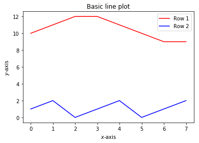

```python
### Basic line plot
# We are plotting the first and second row as separate curves
plt.figure(1)  # Create a new figure object
plt.plot(data[0, :], 'r', data[1, :], 'b')  # Plot the data
# Never forget to label your data and describe your axes
plt.legend(('Row 1', 'Row 2'))
plt.xlabel('$x$-axis')
plt.ylabel('$y$-axis')
plt.title('Basic line plot');
```

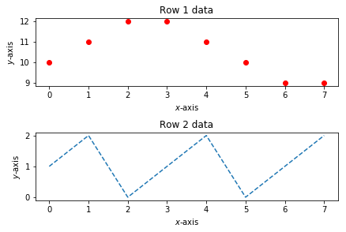

```python
## Basic line plot
# We can also assign a name to our axes object and work with that
fig, (ax1, ax2) = plt.subplots(2, 1)

ax1.plot(data[0, :], 'ro')  # 'r' is coloring the curve in red. 'o' creates a dot plot
ax1.set_title('Row 1 data')
ax1.set_xlabel('$x$-axis')
ax1.set_ylabel('$y$-axis')

# Add another subplot for the second row
ax2.plot(data[1, :], 'C0', linestyle='dashed')  # C<nr> are shorthand notation for the default colors
ax2.set_title('Row 2 data')
ax2.set_xlabel('$x$-axis')
ax2.set_ylabel('$y$-axis')

fig.tight_layout(pad=0.4, w_pad=0.5, h_pad=1.0)  # When you have overlapping plots
```

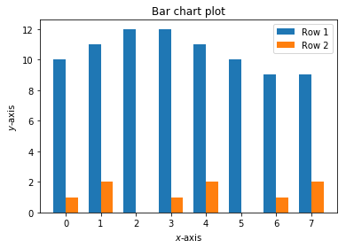

```python
## Barchart
# We are creating a barchart for both rows separately
width = 0.35  # Create a width for the bars
fig2 = plt.figure(3)
bx = fig2.add_subplot(1, 1, 1)
bx.bar(np.arange(np.size(data, axis=1)) - width / 2, data[0, :], width=width)
bx.bar(np.arange(np.size(data, axis=1)) + width / 2, data[1, :], width=width)
bx.legend(('Row 1', 'Row 2'))
bx.set_title(('Bar chart plot'))
bx.set_xlabel('$x$-axis')
bx.set_ylabel('$y$-axis');
```

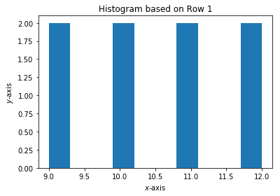

```python
## Histogram
fig3 = plt.figure(4)
ax4 = fig3.add_subplot(1,1,1)
ax4.hist(data[0,:], bins = 10)
ax4.set_title('Histogram based on Row 1')
ax4.set_xlabel('$x$-axis')
ax4.set_ylabel('$y$-axis');
```

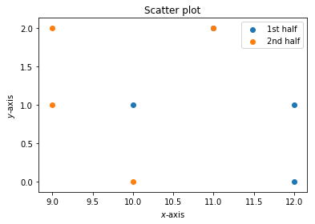

```python
## Scatter plot
# For the scatter plot, we need information about x and y
fig4 = plt.figure(5)
ax5 = fig4.add_subplot(1,1,1)
ax5.scatter(data[0,:4], data[1,:4])
ax5.scatter(data[0,4:], data[1,4:])
ax5.legend(('1st half', '2nd half'))
ax5.set_title('Scatter plot')
ax5.set_xlabel('$x$-axis')
ax5.set_ylabel('$y$-axis');
```

## Interactivity

One of the key advantage of Jupyter notebooks is the easy way to include interactive widgets.

```python
%matplotlib widget
from ipywidgets import interact
import ipywidgets as widgets

fig, ax = plt.subplots(1, 1)

def plot_sin(frequency):
    ax.clear()

    x = np.linspace(-3, 3)
    ax.plot(x, np.sin(frequency * x))
    ax.set_xlabel('$x$')
    ax.set_ylabel(r'$\sin(\omega \cdot x)$')
    ax.set_title(r'$\omega = %.2f$' % frequency)
    ax.set_ylim([-1, 1])

frequency_slider = widgets.FloatSlider(min=-2, max=2, description='$\omega$:')
interact(plot_sin, frequency=frequency_slider);
```

## Machine Learning with Python

Python offers some useful packages that contain machine learning algorithms. One of them is the **sklearn** package. It includes several algorithms like the kNN, Decision Tree, Random Forest, LDA, QDA, SGD, ...  
Documentation and examples can be found on their homepage: http://scikit-learn.org/stable/. There are also several blogs about the use of the tools around the net, i.e. on Machinelearningmastery for kNN: https://machinelearningmastery.com/tutorial-to-implement-k-nearest-neighbors-in-python-from-scratch/.  
Packages can be imported using the following command (i.e. for kNN or Decision Tree):

```
from sklearn.neighbors import KNeighborsClassifier
from sklearn.tree import DecisionTreeClassifier
```

We do not go further into detail here as there will be opportunities in due course.

## Other useful packages

### Pandas

There is quite a broad variety of packages that can be used with Python. One of them is the **pandas** package. It can be used for data manipulation and analysis. The documentation as well as some examples can be found here: http://pandas.pydata.org/pandas-docs/stable/. They also have a nice introduction tutorial that can be found here: https://pandas.pydata.org/pandas-docs/stable/10min.html.

### Seaborn

For the visualizations, we used the matplotlib library. But there are a lot more libraries that can be used. One of them is **seaborn**. It is a powerful visualization tool for statistics and based on the matplotlib library. Some useful tutorials can be found on their page: https://seaborn.pydata.org/tutorial.html.